# Dissociation and PTSD - Data Analysis

Sebastián Opazo

2023-05-28

(This is an R Markdown document. Markdown is a simple formatting syntax for authoring HTML, PDF, and MS Word documents. For more details on using R Markdown see http://rmarkdown.rstudio.com.

The sourcecode of this project can be found here:

https://github.com/Sebastianopazo/ptsd-dissociation

# 1 Documentation

A good description of the original sample used can be found here: https://www.ncbi.nlm.nih.gov/pmc/articles/PMC8890535/

Originally, a total of 1,140 individuals were assessed for elegibility. Of them, 251 (22.0%) did not meet the enrolment criteria, and 668 (58.6%) declined to participate. Finally, 221 individuals were enrolled and randomized (19.4% of those screened). Almost all of them received their allocated intervention (n = 217, 98.2%), the same proportion in the experimental and control groups. One individual in each intervention arm dropped out immediately after randomization and before the intervention was implemented.

In addition to the original 221 participants, a sample of 166 more participants were added (a second wave of recruitment).

# 2 Descriptives

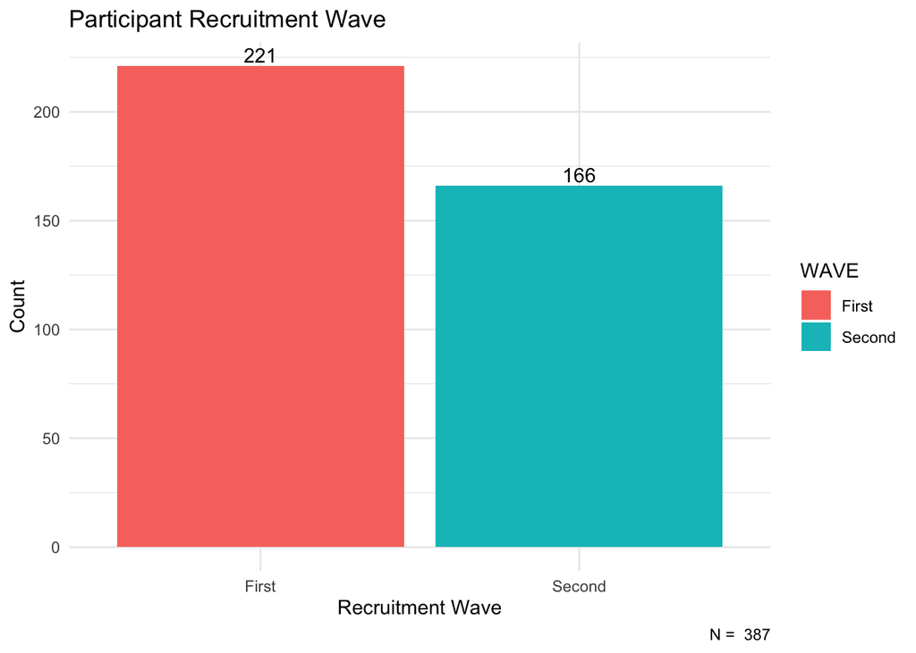

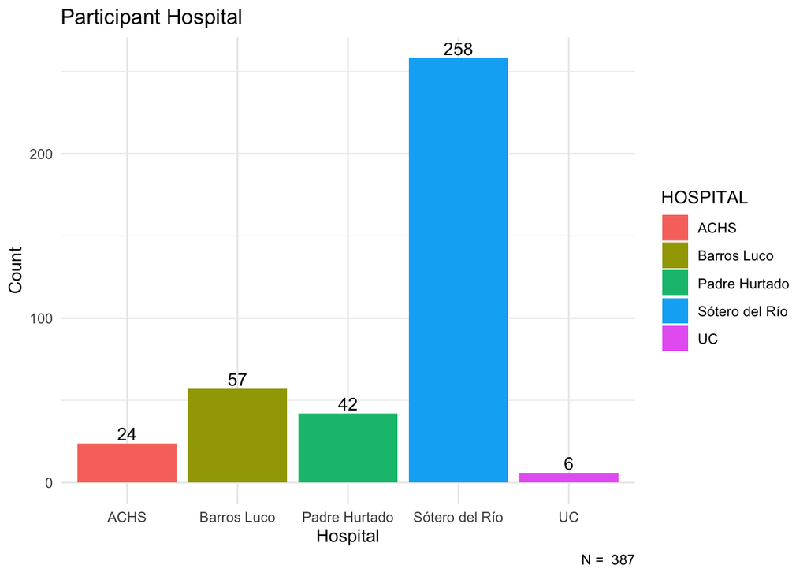

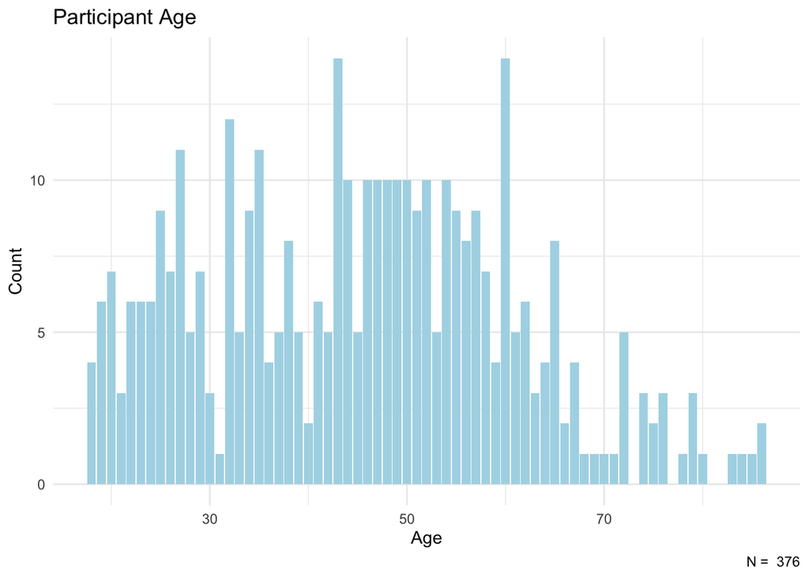

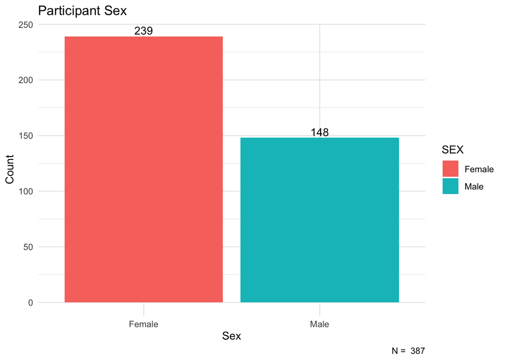

# 3 Mediation Analysis